# **Название исследования**

# 4 Модель 2

## 4.1 Анализ конечной точки 2 модели

Воздействие - курения матери во время беременности,

Исход - осложнения во время родов

Конфаундеры, влияющие напрямую - употребление алкоголя матерью, возраст матери

Конфаундеры, которые напрямую не влияют на воздействие и/или исход - раса матери, образование матери, медицинские риски, пренатальный уход Медиаторы - вес ребенка Нейтральные, влияющие на исход - пол ребенка, кол-во предыдущих родов и метод родов Нейтральные переменные - младенческая смерть

## 4.2 DAG и отбор ковариат модели

DAGitty предлагает целых 5 вариантов минимально достаточных групп конфаундеров для оценки прямого влияния курения матери на вероятность возникновения осложнений при родах

Тип родов, медицинские риски, возраст матери, употребление алкоголя матерью

Медицинские риски, возраст, образование, раса матери, употребление алкоголя матерью

Медицинские риски, возраст матери, употребление алкоголя матерью, количество предыдущих родов

Возраст матери, употребление алкоголя матерью, образование матери, раса матери, дородовой уход

Возраст матери, употребление алкоголя матерью, количество предыдущих родов, дородовой уход

Считаем, что в итоговую модель стоит включить прямые конфаундеры - употребление алкоголя матерью и возраст матери. А также остальные конфаундеры, которые имеют большее отношение именно к родам - медицинские риски, пренатальный уход, а также раса и образование матери. Нейтральные переменные - не включаем

DAGitty предлагает не все конфаундеры одновременно, или предлагает добавить в модель медиаторы, возможно, так как переменные так же связаны друг с другом каузальными связями

```r
DAG2 <- readxl::read_excel("DAG2.xlsx")

DAG2
```

```
## # A tibble: 13 × 3
##    Переменная                     Роль                `Как назвать?`
##    <chr>                          <chr>               <chr>
##  1 Mother's smoking               Воздействие         <NA>
##  2 Complication of labor/delivery Исход               <NA>
##  3 Mother's age                   Конфаундер          <NA>
##  4 Mother's race                  Конфаундер          Напрямую на воздействие и…
##  5 Mother's alcohol drinking      Конфаундер          ещё опосредует влияние Mo…
##  6 Mother's education             Конфаундер          Напрямую на воздейтсиве и…
##  7 Medical risks                  Конфаундер          Напряму на исход и опосре…
##  8 Prenatal care                  Конфаундер          Напряму на воздейтвие и ч…
##  9 Birthweight                    Медиатор            Ещё опосредует влияние Ch…
## 10 Child's sex                    Competing Exposures Через Birthweight на исход
## 11 Delivery method                <NA>                Влияет на исход. Опосреду…
## 12 Number of previous deliveries  <NA>                Через Birthweight и Deliv…
## 13 Infant death                   Нейтральная         <NA>
```

### 4.2.1 Другие возможные конфаундеры, которые не представлены в данном графе?

Предполагаем, что исследователь не представил на графе в качестве конфаундера переменную “Marital status of mother”.

Предполагаем, что данный параметр может быть конфаундером, т.к. условия жизни матери во время беременности, а именно отсутствие семьи, может спровоцировать курение матери, что влияет и на вес новорожденного.

Предполагаем, что включение этого конфаундера в модель незначительно повлияет на результат работы модели, поэтому не включено в даг.

Помимо данных, представленных в датасете, конфаудерами могли бы быть: - Условия жизни матери во время беременности, - Уровень стресса во время беременности, - Сопутствующие заболевания матери.

## 4.3 Измерение ключевых показателей:

Измерение курения матери во время беременности - Осложнения во время родов Ковариаты в модели: Употребление алкоголя матерью Возраст матери Образование матери Расовая принадлежность матери Пренатальный уход

## 4.4 **Дизайн исследования**

Данное исследование представляет собой кросс-секционное (поперечное) исследование, основанное на анализе собранных данных о беременности и родах. В исследовании приняли участие 537 женщин, данные о которых были получены из медицинской документации и опросников. Особенностью данного дизайна является то, что все переменные измерялись одновременно, в период родоразрешения, что позволяет оценить существующие ассоциации между изучаемыми факторами, но не устанавливать временную последовательность событий. Для повышения валидности получаемых результатов в данном исследовании применяются методы статистического контроля конфаундинга на основе предварительно построенного причинно-следственного графа (DAG), что позволяет минимизировать смещение оценок и более обоснованно интерпретировать обнаруженные ассоциации.

## 4.5 **Конечные точки**

Модель 1: Влияние курения на вес при рождении Конечная точка: Переменная: dbirwt (вес при рождении в граммах) Тип: Непрерывная количественная переменная Параметр оценки: Средняя разница веса (β-коэффициент) Метод анализа: Множественная линейная регрессия

Модель 2: Влияние курения на вероятность осложнений при родах Конечная точка: Переменная: labor (осложнения во время родов) Тип: Бинарная переменная (0 = нет осложнений, 1 = есть осложнения) Параметр оценки: Отношение шансов (OR - Odds Ratio) Метод анализа: Логистическая регрессия

## 4.6 **Описательные статистики**

Для описания исходных данных использовались следующие описательные статистики: Для непрерывных переменных: -Среднее значение и стандартное отклонение -Медиана -Минимум и максимум -Визуализация распределения с помощью гистограмм и боксплотов. Для категориальных переменных: -Абсолютные частоты (n) -Относительные частоты (%) -Визуализация с помощью столбчатых диаграмм

## 4.7 **Анализ дополнительных конечных точек**

…

# 5 **Результаты**

## 5.1 **Описательная статистика и эксплораторный анализ**

```r
library(readxl)
library(tidyverse)
library(gtsummary)
library(ggplot2)
library(patchwork)
library(ggmosaic)
data <- read_excel("data/raw/HW_data.xlsx")
dictionary <- read_excel("data/raw/HW_dictionary.xlsx")

variable_dict <- setNames(dictionary$label, dictionary$variable)

categorical_table <- data %>%
  select(labor, tobacco, alcohol, medrisk, death, mrace3, dmeduc3, adequacy, delmeth, csex, drink) %>%
  mutate(across(c(labor, tobacco, alcohol, medrisk, death),
                ~factor(., levels = c("0", "1"), labels = c("No", "Yes")))) %>%
  rename_with(~ variable_dict[.x], .cols = any_of(names(variable_dict))) %>%
  tbl_summary(
    type = all_categorical() ~ "categorical",
    statistic = all_categorical() ~ "{n} ({p}%)",
    missing_text = "Missing"
  ) %>%
  modify_header(label = "**Категориальные переменные**") %>%
  modify_caption("**Таблица 1A. Категориальные переменные**")

continuous_table <- data %>%
  select(dmage, dbirwt, dtotord, dmeduc, monpre, nprevist, gestat, cigar) %>%
  rename_with(~ variable_dict[.x], .cols = any_of(names(variable_dict))) %>%
  tbl_summary(
    type = all_continuous() ~ "continuous2",
    statistic = all_continuous() ~ c("{mean} ({sd})", "{median}", "{min}, {max}"),
    digits = all_continuous() ~ 2,
    missing_text = "Missing"
  ) %>%
  modify_header(
    label = "**Числовые переменные**",
    stat_0_1 = "**Mean (SD)**",
    stat_0_2 = "**Median**",
    stat_0_3 = "**Min, Max**"
  ) %>%
  modify_caption("**Таблица 1B. Числовые переменные**")
```

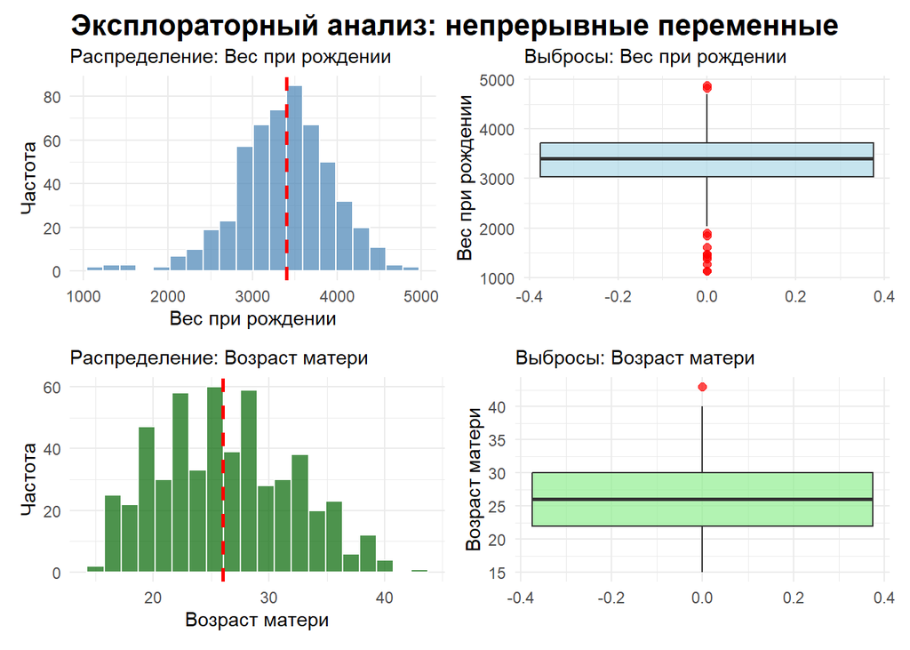

```r
plot_continuous_dist <- function(data, var, var_name, color) {
  ggplot(data, aes(x = {{var}})) +
    geom_histogram(bins = 20, fill = color, alpha = 0.7, color = "white") +
    geom_vline(aes(xintercept = median({{var}}, na.rm = TRUE)),
               color = "red", linetype = "dashed", size = 1) +
    labs(title = paste("Распределение:", var_name),
         x = var_name, y = "Частота") +
    theme_minimal() +
    theme(plot.title = element_text(size = 11))
}

plot_boxplot <- function(data, var, var_name, color) {
  ggplot(data, aes(y = {{var}})) +
    geom_boxplot(fill = color, alpha = 0.7, outlier.color = "red", outlier.size = 2) +
    labs(title = paste("Выбросы:", var_name),
         y = var_name) +
    theme_minimal() +
    theme(plot.title = element_text(size = 11))
}

plot_categorical <- function(data, var, var_name, color) {
  data %>%
    count({{var}}) %>%
    mutate(prop = n/sum(n),
           category = as.character({{var}})) %>%
    ggplot(aes(x = reorder(category, prop), y = prop)) +
    geom_col(fill = color) +
    coord_flip() +
    labs(title = paste("Распределение:", var_name),
         x = "", y = "Доля") +
    scale_y_continuous(labels = scales::percent) +
    theme_minimal() +
    theme(plot.title = element_text(size = 11))


}

plot_by_smoking <- function(data, var, var_name, color_palette = c("lightgreen", "coral")) {
  ggplot(data, aes(x = factor(tobacco), y = {{var}}, fill = factor(tobacco))) +
    geom_boxplot(alpha = 0.7) +
    labs(title = paste(var_name, "по статусу курения"),
         x = "Курение во время беременности",
         y = var_name) +
    scale_x_discrete(labels = c("Не курит", "Курит")) +
    scale_fill_manual(values = color_palette, guide = "none") +
    theme_minimal() +
    theme(plot.title = element_text(size = 11))

}

p1 <- plot_continuous_dist(data, dbirwt, "Вес при рождении", "steelblue")
p2 <- plot_boxplot(data, dbirwt, "Вес при рождении", "lightblue")
p3 <- plot_continuous_dist(data, dmage, "Возраст матери", "darkgreen")
p4 <- plot_boxplot(data, dmage, "Возраст матери", "lightgreen")

(p1 + p2) / (p3 + p4) +
  plot_annotation(title = "Эксплораторный анализ: непрерывные переменные",
                  theme = theme(plot.title = element_text(size = 16, face = "bold")))
```

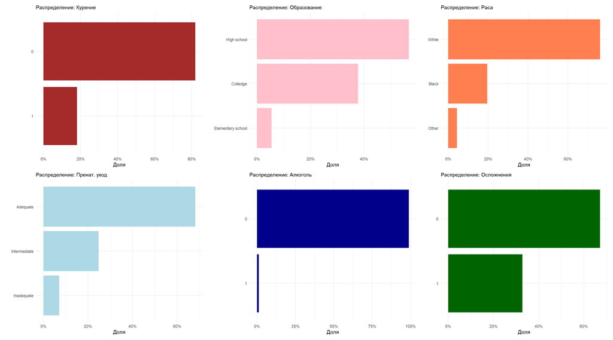

```r
  categorical_plots <- (
    plot_categorical(data, tobacco, "Курение", "brown") +
    plot_categorical(data, dmeduc3, "Образование", "pink") +
    plot_categorical(data, mrace3, "Раса", "coral") +
    plot_categorical(data, adequacy, "Пренат. уход", "lightblue") +
    plot_categorical(data, alcohol, "Алкоголь", "darkblue") +
    plot_categorical(data, labor, "Осложнения", "darkgreen")
  ) + plot_layout(nrow=2, ncol = 3)


categorical_plots
```

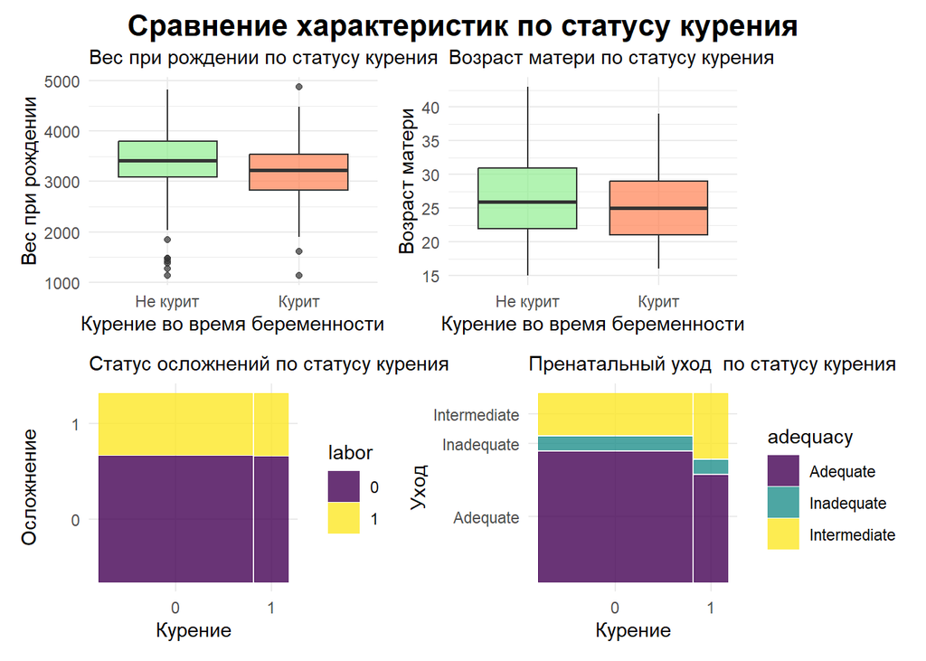

```r
p5 <- plot_by_smoking(data, dbirwt, "Вес при рождении")
p6 <- plot_by_smoking(data, dmage, "Возраст матери")

p7 <- data %>%
  ggplot() +
  geom_mosaic(aes(x = product(tobacco), fill = labor))+
  labs(title = "Статус осложнений по статусу курения",
       x = "Курение", y = "Осложнение") +
  scale_fill_viridis_d() +
  theme_minimal() +
  theme(plot.title = element_text(size = 11))

p8 <- data %>%
  ggplot() +
  geom_mosaic(aes(x = product(tobacco), fill = adequacy)) +
  labs(title = "Пренатальный уход  по статусу курения",
       x = "Курение", y = "Уход") +
  scale_fill_viridis_d() +
  theme_minimal() +
  theme(plot.title = element_text(size = 11))

(p5 + p6) / (p7 + p8) +
  plot_annotation(title = "Сравнение характеристик по статусу курения",
                  theme = theme(plot.title = element_text(size = 16, face = "bold")))
```

```r
additionaltable_cath <- data %>%
  select(death, congenit, newborn) %>%
  mutate(across(c(death, congenit, newborn),
                ~factor(., levels = c("0", "1"), labels = c("No", "Yes")))) %>%
  rename_with(~ variable_dict[.x], .cols = any_of(names(variable_dict))) %>%
  tbl_summary(
    type = all_categorical() ~ "categorical",
    statistic = all_categorical() ~ "{n} ({p}%)",
    missing_text = "Missing"
  ) %>%
  modify_header(label = "**Категориальные переменные**") %>%
  modify_caption("**Таблица 2A. Дополнительные конечные точки: Категориальные переменные**")




additionaltable_col <- data %>%
  select(gestat) %>%
  rename_with(~ variable_dict[.x], .cols = any_of(names(variable_dict))) %>%
  tbl_summary(
    type = all_continuous() ~ "continuous2",
    statistic = all_continuous() ~ c("{mean} ({sd})", "{median}", "{min}, {max}"),
    digits = all_continuous() ~ 2,
    missing_text = "Missing"
  ) %>%
  modify_header(
    label = "**Числовые переменные**",
    stat_0_1 = "**Mean (SD)**",
    stat_0_2 = "**Median**",
    stat_0_3 = "**Min, Max**"
  ) %>%
  modify_caption("**Таблица 2B. Дополнительные конечные точки: Числовые переменные**")

additionaltable_cath
```

**Таблица 2A. Дополнительные конечные точки: Категориальные переменные**

| **Категориальные переменные** | **N = 537**<sup>1</sup> |
| --- | --- |
| Infant death |  |
| No | 536 (100%) |
| Yes | 1 (0.2%) |
| Any congenital anomalies |  |
| No | 0 (0%) |
| Yes | 537 (100%) |
| Any abnormal conditions of the newborn |  |
| No | 503 (94%) |
| Yes | 34 (6.3%) |

<sup>1</sup> n (%)

```r
additionaltable_col
```

**Таблица 2B. Дополнительные конечные точки: Числовые переменные**

| **Числовые переменные** | **N = 537** |
| --- | --- |
| Gestation in weeks |  |
| Mean (SD) | 39.28 (2.40) |
| Median | 39.00 |
| Min, Max | 28.00, 47.00 |

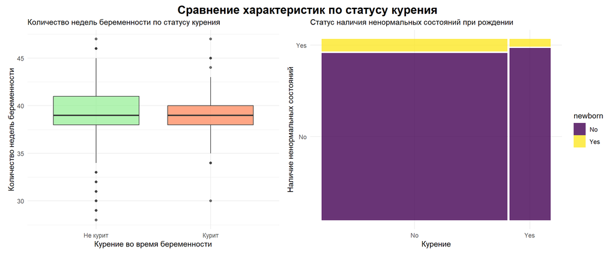

```r
p9 <- plot_by_smoking(data, gestat, "Количество недель беременности")

p10 <- data %>%
    mutate(across(c(tobacco, newborn),
                ~factor(., levels = c("0", "1"), labels = c("No", "Yes")))) %>%
  ggplot()+
  geom_mosaic(aes(x = product(tobacco), fill = newborn))+
  labs(title = "Статус наличия ненормальных состояний при рождении",
       x = "Курение", y = "Наличие ненормальных состояний") +
  scale_fill_viridis_d() +
  theme_minimal() +
  theme(plot.title = element_text(size = 11))

(p9 + p10) +
  plot_annotation(title = "Сравнение характеристик по статусу курения",
                  theme = theme(plot.title = element_text(size = 16, face = "bold")))
```

## 5.2 **Результаты эксплораторного анализа конечной точки 1**

Диапазон значений веса при рождении варьировал от 1134.00 грамм до 4876.00 грамм, что отражает значительную вариабельность изучаемого показателя в выборке. Наличие случаев с экстремально низким весом (1134 г) может быть связано с недоношенностью, задержкой внутриутробного развития или другими патологическими состояниями, в то время как максимальные значения приближаются к верхней границе нормального веса доношенных новорожденных.

Сравнение среднего значения с общепопуляционными нормами (обычно 2500-4000 г для доношенных детей) показывает, что исследуемая выборка в целом соответствует ожидаемым параметрам, однако наличие случаев как с очень низким, так и с высоким весом требует дополнительного анализа потенциальных факторов, влияющих на этот показатель.

Размер стандартного отклонения (около 17% от среднего значения) указывает на умеренную вариабельность веса при рождении в изучаемой популяции, что является типичным для данного антропометрического показателя.

## 5.3 Результаты анализа конечной точки 1

```r
fit1 <- lm(data$dbirwt ~ data$cigar, data)
```

Построение линейной модели с учетом смешивающих факторов позволяет исключить выявленные нарушения усливий применения линейной модели (см. график зависимости остатков от предсказанных значений из приложения 4)

```r
fit2 <- lm(data$dbirwt ~ data$cigar + data$drink + data$dmage + data$medrisk + data$adequacy + data$mrace3 + data$dmeduc3, data)
```

При детальном рассмотрении графиков зависимости остатков от каждой переменной (Приложение 5) невозможно оценивать линейность зависимости для перменных количества сигарет и количества выпитых, т.к. большинство этих перменных равны 0.

## 5.4 **Результаты эксплораторного анализа конечной точки 2**

Распределение осложнений во время родов и/или родоразрешения в исследуемой выборке показывает следующую картину:

В общей сложности осложнения были зарегистрированы у 176 женщин (33%) из 537 наблюдений (Приложение 1). Это означает, что примерно каждая третья женщина в исследовании столкнулась с теми или иными осложнениями в процессе родов.

Большинство родов (67%) прошли без осложнений - такая картина наблюдалась у 361 женщины. Полученное соотношение 2:1 (два случая неосложненных родов на один случай с осложнениями) указывает на то, что хотя осложнения являются частым явлением, нормальное течение родов все же преобладает в изучаемой популяции.

## 5.5 **Результаты анализа дополнительных конечных точек**

…

Среднее значение недели родов (39 недель со страндартным отклонением 2.4) соответсвует нормальным срокам родоразрешения. Неделя, на которой происходили роды варьировал от 28 до 47 недель. При этом количество женщин, родивших раньше 35 недели больше в группе не курящих женщин.

Ненормлаьные состояния после рождения зарегистрированы только в 6,3 % случаев в больншинстве у не курящих женщин.

…

# 6 **Ограничения**

# 7 **Выводы**

# 8 **Источники литературы**

1. Delcroix M.-H., Delcroix-Gomez C., Marquet P., Gauthier T., Thomas D., Aubard Y. Active or passive maternal smoking increases the risk of low birth weight or preterm delivery: Benefits of cessation and tobacco control policies//Tobacco Induced Diseases, 2023, Vol. 21, Active or passive maternal smoking increases the risk of low birth weight or preterm delivery, No. May, P. 1-13.
2. Hamadneh S., Hamadneh J. Active and Passive Maternal Smoking During Pregnancy and Birth Outcomes: A Study From a Developing Country//Annals of Global Health, 2021, Vol. 87, Active and Passive Maternal Smoking During Pregnancy and Birth Outcomes, No. 1. …

# 9 **Использование ИИ**

# 10 **Приложения**

## 10.1 **Приложение 1**

```r
categorical_table
```

**Таблица 1A. Категориальные переменные**

| **Категориальные переменные** | **N = 537**<sup>1</sup> |
| --- | --- |
| Any complications of labor and/or delivery |  |
| No | 361 (67%) |
| Yes | 176 (33%) |
| Tobacco use during pregnancy |  |
| No | 440 (82%) |
| Yes | 97 (18%) |
| Alcohol use during pregnancy |  |
| No | 531 (99%) |
| Yes | 6 (1.1%) |
| Any medical risk factor during this pregnancy |  |
| No | 458 (85%) |
| Yes | 79 (15%) |
| Infant death |  |
| No | 536 (100%) |
| Yes | 1 (0.2%) |
| Race of mother |  |
| Black | 105 (20%) |
| Other | 23 (4.3%) |
| White | 409 (76%) |
| Education of mother |  |
| Colledge | 203 (38%) |
| Elementary school | 29 (5.4%) |
| High school | 305 (57%) |
| Adequacy of prenatal care (Kessner index) |  |
| Adequate | 366 (68%) |
| Inadequate | 38 (7.1%) |
| Intermediate | 133 (25%) |
| Method of delivery |  |
| Primary C-section | 77 (14%) |
| Repeat C-section | 44 (8.2%) |
| Vaginal | 405 (75%) |
| Vaginal after previous C-section | 11 (2.0%) |
| Child's sex |  |
| Female | 263 (49%) |
| Male | 274 (51%) |
| Average number of drinks per day |  |
| 0 | 531 (99%) |
| 1 | 1 (0.2%) |
| 2 | 2 (0.4%) |
| 3 | 2 (0.4%) |
| 6 | 1 (0.2%) |

<sup>1</sup> n (%)

## 10.2 **Приложение 2**

```r
continuous_table
```

**Таблица 1B. Числовые переменные**

| **Числовые переменные** | **N = 537** |
| --- | --- |
| Age of mother in years |  |
| Mean (SD) | 26.32 (5.77) |
| Median | 26.00 |
| Min, Max | 15.00, 43.00 |
| Birth weight in grams |  |
| Mean (SD) | 3,366.58 (573.59) |
| Median | 3,402.00 |
| Min, Max | 1,134.00, 4,876.00 |
| Total birth order |  |
| Mean (SD) | 2.36 (1.55) |
| Median | 2.00 |
| Min, Max | 1.00, 12.00 |
| Missing | 1 |
| Education of mother in years |  |
| Mean (SD) | 12.44 (2.55) |
| Median | 12.00 |
| Min, Max | 0.00, 17.00 |
| Month of pregnancy prenatal care began |  |
| Mean (SD) | 2.67 (1.50) |
| Median | 2.00 |
| Min, Max | 0.00, 9.00 |
| Total number of prenatal visits |  |
| Mean (SD) | 11.06 (3.95) |
| Median | 12.00 |
| Min, Max | 0.00, 28.00 |
| Gestation in weeks |  |
| Mean (SD) | 39.28 (2.40) |
| Median | 39.00 |
| Min, Max | 28.00, 47.00 |
| Average number of cigarettes per day |  |
| Mean (SD) | 2.42 (5.91) |
| Median | 0.00 |
| Min, Max | 0.00, 30.00 |

## 10.3 **Приложение 3**

[figure not shown]

```r
resid_panel(fit1, plots = "resid", smoother = TRUE)
```

## 10.4 **Приложение 4**

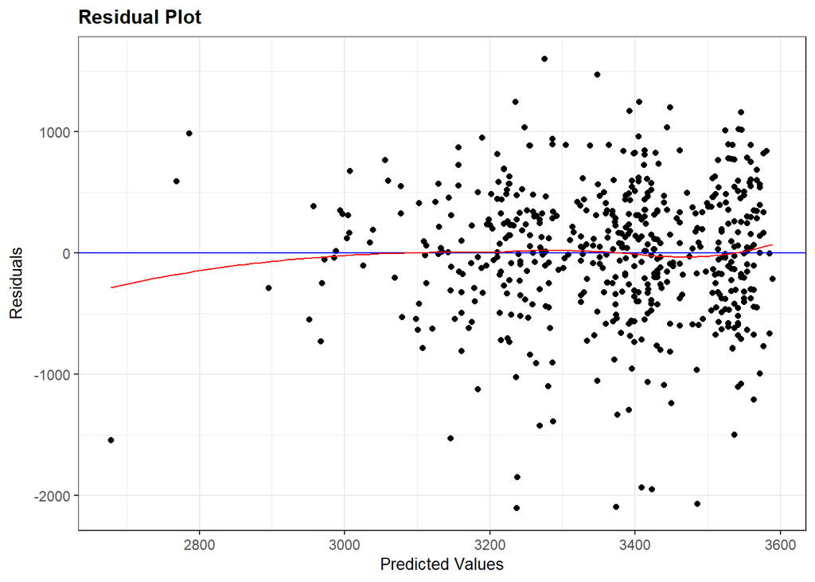

```r
resid_panel(fit2, plots = "resid", smoother = TRUE)
```

## 10.5 **Приложение 5**

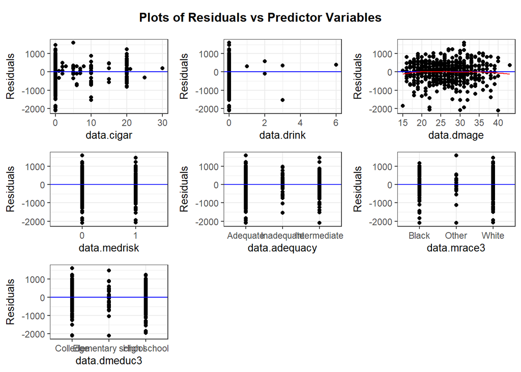

```r
resid_xpanel(fit2, smoother = TRUE)
```